# Breeding Bird Surveys - Cleveland Metroparks: Occupancy modelling

Nathan W. Byer

2022-10-27

# The dataset

Tim Krynak, Erik Shaffer, Jen Brumfield, and other Cleveland Metroparks and affiliated colleagues conducted Breeding Bird Surveys (BBS) at a total of 211 routes between 2017 and 2021. 164 of these routes overlapped with long-term vegetation monitoring efforts through the Cleveland Metroparks Plant Community Assessment Program (PCAP). This provided an excellent opportunity to explore the potential relationships between vegetative composition, landscape structure, and breeding bird ecology and community composition.

# Initial processing

First, we just read in the full BBS dataset. For our purposes, we will remove any BBS observations not paired with PCAP plots. We can also visualize the distribution of survey effort through time.

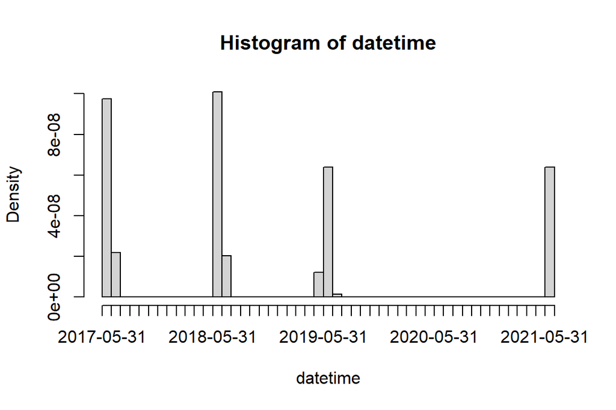

```r
CMP_bbs_pcap_join<-read.csv("G:/NaturalResources/Byer/datasets/BBS/CMP_bbs_pcapjoin_elimWC_EATO.csv",header=T)
CMP_bbs_pcap_join_pcaponly<-CMP_bbs_pcap_join[!is.na(CMP_bbs_pcap_join$Plot.ID),]

datetime<-strptime(CMP_bbs_pcap_join_pcaponly$survey_cre,format="%m/%d/%Y %H:%M")
hist(datetime,breaks="months")
```

```r
pcap_1styear_landscape<-read.csv("G:/NaturalResources/Byer/datasets/BBS/pcap_4yr_landscape_variables_revLDI.csv",header=T)
```

Next, we need to start grouping this dataset for downsteram analysis. This involves summarizing counts of each species for each plot. We also replace any NA values in the data frame with zeroes - this will be important for downstream applications, as we want to distinguish between unobserved species at a plot and check (typically coded 0s) and checks that were “skipped” (NAs).

```r
CMP_bbs_pcap_join_pcaponly_pcapsum<-CMP_bbs_pcap_join_pcaponly %>%
  group_by(simp_plot, reservatio,community,species_4_) %>%
  summarise(n=n(),longitude=mean(xcoord), latitude=mean(ycoord),vibifq=mean(vibi_fq),vibifqnotrees=mean(vibi_fq_no_trees),carex=mean(carex_metric_value),cyper=mean(cyperaceae_metric_value),
            dicot=mean(dicot_metric_value),shade=mean(shade_metric_value),shrub=mean(shrub_metric_value),
            hydro=mean(hydrophyte_metric_value),svp=mean(svp_metric_value),ap=mean(ap_ratio_metric_value),
            fqi=mean(fqai_score),bryo=mean(bryophyte_metric_value),hydro_rel=mean(hydrophyte_rel_cov_metric_value),
            hydro_rel_notrees=mean(hydrophyte_rel_cov_no_trees),
            sens_rel=mean(sensitive_rel_cov_metric_value),
            sens_rel_notree=mean(sensitive_rel_cov_no_trees),
            tol_rel=mean(tolerant_rel_cov_metric_value),
            tol_rel_notree=mean(tolerant_rel_cov_no_trees),
            inv=mean(invasive_graminoids_metric_value),
            small_tree=mean(small_tree_metric_value),
            subcanopy=mean(subcanopy_iv),
            canopy=mean(canopy_iv.1)
            ) %>%
  spread(species_4_,n) %>%
  replace(is.na(.),0)

names(pcap_1styear_landscape)[names(pcap_1styear_landscape) == 'site.name'] <- 'simp_plot'

class(pcap_1styear_landscape$simp_plot)<-"character"

class(CMP_bbs_pcap_join_pcaponly_pcapsum$simp_plot)<-"character"


CMP_bbs_pcap_join_pcaponly_pcapsum_landscape<-left_join(x = CMP_bbs_pcap_join_pcaponly_pcapsum,y = pcap_1styear_landscape,by="simp_plot")

CMP_bbs_pcap_join_pcaponly_pcapsum<-column_to_rownames(CMP_bbs_pcap_join_pcaponly_pcapsum_landscape,var="simp_plot")
```

This is a pretty unwieldly dataset at present - we have 164 rows (representing our BBS/PCAP plots) and 131 columns. Out of those 131 columns, 103 are unique species (designated with four-letter codes), so most of the first 27 covariates are essentially our “predictors” - in this case, our PCAP data.

Let’s do a bit more processing on this dataset to get it in shape for downstream analyses. First, we will separate out our bird community data.

```r
birdcomm<-CMP_bbs_pcap_join_pcaponly_pcapsum[,28:(130)]

birdcomm[is.na(birdcomm)] <- 0
```

Next, we separate out our PCAP data.

```r
vegecomm<-CMP_bbs_pcap_join_pcaponly_pcapsum[,5:26]
```

Finally, we will separate out the 1st year landscape covariates. As a quick note, these will not be *strictly* comparable with the 2nd survey landscape covariates, but should be pretty close (~5 years is likely not enough for substantial land cover change).

```r
landcomm<-CMP_bbs_pcap_join_pcaponly_pcapsum[,c(142:152,156,157)]

landcomm[is.na(landcomm)] <- 0
```

Since we are using the PCAP dataset as predictors here, we should likely check for correlations between these covariates. I have selected a (semi-)arbitrary cut-off of 0.6 to identify covariates as correlated; we then drop any covariates that are likely redundant.

```r
vegecomm_cor<-cor(vegecomm)

set.seed(12345)
corvar<-findCorrelation(vegecomm_cor,cutoff=0.6)

vegecomm_drop<-vegecomm[,-corvar]
```

We can also check for correlations between the landscape covariates.

```r
cols<-seq(1,13,1)

landcomm[,cols] = apply(landcomm[,cols], 2, function(x) as.numeric(as.character(x)))

landcomm_cor<-cor(landcomm)

set.seed(12345)
corvar_land<-findCorrelation(landcomm_cor,cutoff=0.6)

landcomm_drop<-landcomm[,-corvar_land]
```

We can then check correlations between PCAP and landscape covariates.

```r
landvegcomm_drop<-cbind(vegecomm_drop,landcomm_drop)

landvegcomm_drop_cor<-cor(landvegcomm_drop)

set.seed(12345)
corvar_landveg<-findCorrelation(landvegcomm_drop_cor,cutoff=0.6)
```

No covariates were overly correlated in this dataset, so we can proceed.

Now, we have:

1. a vegecomm dataset - which representing PCAP measurements for each of the 164 BBS/PCAP plots.
2. a birdcomm dataset - representing presence/absence of each bird species for each survey in each plot.
3. a landcomm dataset - representing landscape covariates associated with these PCAP plots.

Note that we are not explicitly considering differences in bird counts (or occupancy, or detectability) through time at this point - we will get to that later. For now, we just want to explore broad associations between these three datasets!

Note as of 6/13/2022 - we will also want to only work with only binary data.

# multi-species occupancy modelling

```
##   [1] 1002 1003 1004 1005 1006 1008 1009 1011 1012 1013 1014 1015 1016 1017 1018 1019 1021 1022 1024 1025 1026 1028 1029 1030 1031 1033 1034 1035 1038 1039 1040 1041 1043 1044 1045 1046 1047 1048 1050 1051 1052 1053 1054 1055 1057 1058 1059 1060 1061 1063 1064 1065 1066 1067 1068 1069 1070 1071 1…
## Levels: 1002 1003 1004 1005 1006 1008 1009 1011 1012 1013 1014 1015 1016 1017 1018 1019 1021 1022 1024 1025 1026 1028 1029 1030 1031 1033 1034 1035 1038 1039 1040 1041 1043 1044 1045 1046 1047 1048 1050 1051 1052 1053 1054 1055 1057 1058 1059 1060 1061 1063 1064 1065 1066 1067 1068 1069 1070 1071…
```

```
##  [1] Tim Krynak      Rem Moll        Bill Deininger  Dwight Chasar   Brian Slaby     Kurt Grenig     Nancy Howell    Jen Brumfield   Patti Donnellan Erik Shaffer    Matt Kneitel    Hvidos
## Levels: Bill Deininger Brian Slaby Dwight Chasar Erik Shaffer Hvidos Jen Brumfield Kurt Grenig Matt Kneitel Nancy Howell Patti Donnellan Rem Moll Tim Krynak
```

```
##        V1              V2               V3               V4            V5              V6               V7               V8
##  Min.   :0.000   Min.   :0.0000   Min.   :0.0000   Min.   :0.0   Min.   :0.000   Min.   :0.0000   Min.   :0.0000   Min.   :0.0000
##  1st Qu.:0.000   1st Qu.:0.0000   1st Qu.:0.0000   1st Qu.:0.0   1st Qu.:0.000   1st Qu.:0.0000   1st Qu.:0.0000   1st Qu.:0.2500
##  Median :0.000   Median :0.0000   Median :1.0000   Median :1.0   Median :1.000   Median :1.0000   Median :1.0000   Median :1.0000
##  Mean   :0.372   Mean   :0.4938   Mean   :0.5437   Mean   :0.6   Mean   :0.527   Mean   :0.5541   Mean   :0.5208   Mean   :0.6667
##  3rd Qu.:1.000   3rd Qu.:1.0000   3rd Qu.:1.0000   3rd Qu.:1.0   3rd Qu.:1.000   3rd Qu.:1.0000   3rd Qu.:1.0000   3rd Qu.:1.0000
##  Max.   :1.000   Max.   :1.0000   Max.   :1.0000   Max.   :1.0   Max.   :1.000   Max.   :1.0000   Max.   :1.0000   Max.   :1.0000
##                  NA's   :2        NA's   :4        NA's   :89    NA's   :90      NA's   :90       NA's   :116      NA's   :158
```

## making simpler dataset

```r
bbs_occobject_three<-list()

bbs_occobject_three$y<-array(dim=c(103,164,3))

bbs_occobject_three$y <- array(c(as.matrix(firstcheck_birds),as.matrix(secondcheck_birds),
                           as.matrix(thirdcheck_birds)), dim=c(103,164,3))

bbs_occobject_three$det.covs$day<-as.matrix(sitechecks_surveyhistory[,2:4])

seasons<-round(sitechecks_surveyhistory[,2:4]/365)+1

dayyear<-bbs_occobject_three$det.covs$day-((seasons-1)*365)

bbs_occobject_three$det.covs$tod<-as.matrix(sitetimes_surveyhistory[,2:4])

bbs_occobject_three$det.covs$seasons<-as.matrix(seasons)

bbs_occobject_three$det.covs$dayyear<-as.matrix(dayyear)

bbs_occobject_three$det.covs$dist_road<-as.matrix(sitechecks_road_detcov[,2:4])
```

## MSOM - running different models

### setting some basic parameters for the runs

```r
N <- dim(bbs_occobject$y)[1]
ms.inits <- list(alpha.comm = 0,
                 beta.comm = 0,
                 beta = 0,
                 alpha = 0,
                 tau.sq.beta = 1,
                 tau.sq.alpha = 1,
                 z = apply(bbs_occobject$y, c(1, 2), max, na.rm = TRUE))
ms.priors <- list(beta.comm.normal = list(mean = 0, var = 2.72),
                  alpha.comm.normal = list(mean = 0, var = 2.72),
                  tau.sq.beta.ig = list(a = 0.1, b = 0.1),
                  tau.sq.alpha.ig = list(a = 0.1, b = 0.1))
n.samples<-30000
n.omp.threads<-1
n.report<-6000
n.burn<-10000
n.thin<-50
n.chains<-3
```

### setting up our model statements

```r
occ_null <- ~1
occ_vibifq <- ~ scale(vibifq)
occ_vibifqnotrees <- ~ scale(vibifqnotrees)
occ_fqi <- ~ scale(fqi)
occ_rdaveg <- ~ scale(tol_rel) + scale(svp) + scale(dicot) + scale(cyper) + scale(small_tree)
occ_fullrda<- ~ scale(tol_rel) + scale(svp) + scale(dicot) + scale(cyper) +scale(ldi_3k)+scale(developed)
occ_structure <- ~ scale(canopy)+scale(subcanopy)+scale(small_tree)
occ_tol <- ~ scale(tol_rel)
occ_allveg <- ~ scale(tol_rel) + scale(svp) + scale(dicot) + scale(cyper) + scale(small_tree)+scale(shrub)+scale(hydro)+scale(subcanopy)+scale(canopy)
occ_allland <- ~ scale(developed)+scale(activity.area)+scale(sanctioned.trail)+ scale(bootleg.trail)+scale(stream.edge)+scale(ldi_3k)

det_null <- ~1
det_null_randobs<- ~ 1 + I(1|observer)
det_day <- ~ scale(day)
det_day_randobs <- ~ scale(day) + I(1|observer)
det_daytod<- ~ scale(day)+scale(tod)
det_daytod_randobs <- ~ scale(day)+scale(tod)+ I(1|observer)
det_daytodquad <- ~ scale(day)+scale(tod) +I(scale(day)^2)
det_daytodquad_randobs <- ~ scale(day)+scale(tod) +I(scale(day)^2) + I(1|observer)
det_season <- ~ scale(seasons)
det_season_randobs <- ~ scale(seasons) + I(1|observer)
det_dayyearseason <- ~ scale(dayyear) + scale(seasons)
det_dayyearseason_randobs <- ~ scale(dayyear) + scale(seasons) + I(1|observer)
det_dayyeartodseason <- ~ scale(dayyear)+scale(tod)+scale(seasons)
det_dayyeartodseason_randobs <- ~ scale(dayyear)+scale(tod)+scale(seasons) + I(1|observer)
det_dayyeartodseason <- ~ scale(dayyear)+scale(tod)+scale(seasons)
det_dayyeartodseason_randobs <- ~ scale(dayyear)+scale(tod)+scale(seasons)+ I(1|observer)
det_dayyeartodseasonroad <- ~ scale(dayyear)+scale(tod)+scale(seasons)+scale(dist_road)
det_dayyeartodseasonroad_randobs <- ~ scale(dayyear)+scale(tod)+scale(seasons)+scale(dist_road)+I(1|observer)
```

### basic null model

```r
out.ms.null <- msPGOcc(occ.formula = occ_null,
                  det.formula = det_null,
                  data = bbs_occobject,
                  inits = ms.inits,
                  n.samples = n.samples,
                  priors = ms.priors,
                  n.omp.threads = n.omp.threads,
                  verbose = TRUE,
                  n.report = n.report,
                  n.burn = n.burn,
                  n.thin = n.thin,
                  n.chains = n.chains)
summary(out.ms.null)
ppc.out.ms.null <- ppcOcc(out.ms.null, 'chi-squared', group = 1)
summary(ppc.out.ms.null)
```

### basic null model - with random effect

```r
out.ms.nullobs <- msPGOcc(occ.formula = occ_null,
                  det.formula = det_null_randobs,
                  data = bbs_occobject,
                  inits = ms.inits,
                  n.samples = n.samples,
                  priors = ms.priors,
                  n.omp.threads = n.omp.threads,
                  verbose = TRUE,
                  n.report = n.report,
                  n.burn = n.burn,
                  n.thin = n.thin,
                  n.chains = n.chains)
summary(out.ms.nullobs)
ppc.out.ms.nullobs <- ppcOcc(out.ms.nullobs, 'chi-squared', group = 1)
summary(ppc.out.ms.nullobs)
```

### building up complexity of detection model - just day for now

```r
out.ms.det.day <- msPGOcc(occ.formula = occ_null,
                  det.formula = det_day,
                  data = bbs_occobject,
                  inits = ms.inits,
                  n.samples = n.samples,
                  priors = ms.priors,
                  n.omp.threads = n.omp.threads,
                  verbose = TRUE,
                  n.report = n.report,
                  n.burn = n.burn,
                  n.thin = n.thin,
                  n.chains = n.chains)


summary(out.ms.det.day)
ppc.out.ms.det.day <- ppcOcc(out.ms.det.day, 'chi-squared', group = 1)
summary(ppc.out.ms.det.day)
```

### day and random effect

```r
out.ms.detobs.day <- msPGOcc(occ.formula = occ_null,
                  det.formula = det_day_randobs,
                  data = bbs_occobject,
                  inits = ms.inits,
                  n.samples = n.samples,
                  priors = ms.priors,
                  n.omp.threads = n.omp.threads,
                  verbose = TRUE,
                  n.report = n.report,
                  n.burn = n.burn,
                  n.thin = n.thin,
                  n.chains = n.chains)


summary(out.ms.detobs.day)
ppc.out.ms.detobs.day <- ppcOcc(out.ms.detobs.day, 'chi-squared', group = 1)
summary(ppc.out.ms.detobs.day)
```

### day and time-of-day

```r
out.ms.det.daytod <- msPGOcc(occ.formula = occ_null,
                  det.formula = det_daytod,
                  data = bbs_occobject,
                  inits = ms.inits,
                  n.samples = n.samples,
                  priors = ms.priors,
                  n.omp.threads = n.omp.threads,
                  verbose = TRUE,
                  n.report = n.report,
                  n.burn = n.burn,
                  n.thin = n.thin,
                  n.chains = n.chains)
summary(out.ms.det.daytod)
ppc.out.ms.det.daytod <- ppcOcc(out.ms.det.daytod, 'chi-squared', group = 1)
summary(ppc.out.ms.det.daytod)
```

### day and time-of-day - random observer

```r
out.ms.detobs.daytod <- msPGOcc(occ.formula = occ_null,
                  det.formula = det_daytod_randobs,
                  data = bbs_occobject,
                  inits = ms.inits,
                  n.samples = n.samples,
                  priors = ms.priors,
                  n.omp.threads = n.omp.threads,
                  verbose = TRUE,
                  n.report = n.report,
                  n.burn = n.burn,
                  n.thin = n.thin,
                  n.chains = n.chains)
summary(out.ms.detobs.daytod)
ppc.out.ms.detobs.daytod <- ppcOcc(out.ms.detobs.daytod, 'chi-squared', group = 1)
summary(ppc.out.ms.detobs.daytod)
```

### day, tod, quadratic day

```r
out.ms.det.daytodquad<- msPGOcc(occ.formula = occ_null,
                  det.formula = det_daytodquad,
                  data = bbs_occobject,
                  inits = ms.inits,
                  n.samples = n.samples,
                  priors = ms.priors,
                  n.omp.threads = n.omp.threads,
                  verbose = TRUE,
                  n.report = n.report,
                  n.burn = n.burn,
                  n.thin = n.thin,
                  n.chains = n.chains)
summary(out.ms.det.daytodquad)
ppc.out.ms.det.daytodquad <- ppcOcc(out.ms.det.daytodquad, 'chi-squared', group = 1)
summary(ppc.out.ms.det.daytodquad)
```

### day, tod, quadratic day - random observer

```r
out.ms.detobs.daytodquad<- msPGOcc(occ.formula = occ_null,
                  det.formula = det_daytodquad_randobs,
                  data = bbs_occobject,
                  inits = ms.inits,
                  n.samples = n.samples,
                  priors = ms.priors,
                  n.omp.threads = n.omp.threads,
                  verbose = TRUE,
                  n.report = n.report,
                  n.burn = n.burn,
                  n.thin = n.thin,
                  n.chains = n.chains)
summary(out.ms.detobs.daytodquad)
ppc.out.ms.detobs.daytodquad <- ppcOcc(out.ms.detobs.daytodquad, 'chi-squared', group = 1)
summary(ppc.out.ms.detobs.daytodquad)
```

### season alone

```r
out.ms.det.season<- msPGOcc(occ.formula = occ_null,
                  det.formula = det_season,
                  data = bbs_occobject,
                  inits = ms.inits,
                  n.samples = n.samples,
                  priors = ms.priors,
                  n.omp.threads = n.omp.threads,
                  verbose = TRUE,
                  n.report = n.report,
                  n.burn = n.burn,
                  n.thin = n.thin,
                  n.chains = n.chains)
summary(out.ms.det.season)
ppc.out.ms.det.season <- ppcOcc(out.ms.det.season, 'chi-squared', group = 1)
summary(ppc.out.ms.det.season)
```

### season alone - random observer

```r
out.ms.detobs.season<- msPGOcc(occ.formula = occ_null,
                  det.formula = det_season_randobs,
                  data = bbs_occobject,
                  inits = ms.inits,
                  n.samples = n.samples,
                  priors = ms.priors,
                  n.omp.threads = n.omp.threads,
                  verbose = TRUE,
                  n.report = n.report,
                  n.burn = n.burn,
                  n.thin = n.thin,
                  n.chains = n.chains)
summary(out.ms.detobs.season)
ppc.out.ms.detobs.season <- ppcOcc(out.ms.detobs.season, 'chi-squared', group = 1)
summary(ppc.out.ms.detobs.season)
```

### day of year and season

```r
out.ms.det.dayyearseason<- msPGOcc(occ.formula = occ_null,
                  det.formula = det_dayyearseason,
                  data = bbs_occobject,
                  inits = ms.inits,
                  n.samples = n.samples,
                  priors = ms.priors,
                  n.omp.threads = n.omp.threads,
                  verbose = TRUE,
                  n.report = n.report,
                  n.burn = n.burn,
                  n.thin = n.thin,
                  n.chains = n.chains)
summary(out.ms.det.dayyearseason)
ppc.out.ms.det.dayyearseason <- ppcOcc(out.ms.det.dayyearseason, 'chi-squared', group = 1)
summary(ppc.out.ms.det.dayyearseason)
```

### day of year and season - random observer

```r
out.ms.detobs.dayyearseason<- msPGOcc(occ.formula = occ_null,
                  det.formula = det_dayyearseason_randobs,
                  data = bbs_occobject,
                  inits = ms.inits,
                  n.samples = n.samples,
                  priors = ms.priors,
                  n.omp.threads = n.omp.threads,
                  verbose = TRUE,
                  n.report = n.report,
                  n.burn = n.burn,
                  n.thin = n.thin,
                  n.chains = n.chains)
summary(out.ms.detobs.dayyearseason)
ppc.out.ms.detobs.dayyearseason <- ppcOcc(out.ms.detobs.dayyearseason, 'chi-squared', group = 1)
summary(ppc.out.ms.detobs.dayyearseason)
```

### day in year, tod, season

```r
out.ms.det.dayyeartodseason<- msPGOcc(occ.formula = occ_null,
                  det.formula = det_dayyeartodseason,
                  data = bbs_occobject,
                  inits = ms.inits,
                  n.samples = n.samples,
                  priors = ms.priors,
                  n.omp.threads = n.omp.threads,
                  verbose = TRUE,
                  n.report = n.report,
                  n.burn = n.burn,
                  n.thin = n.thin,
                  n.chains = n.chains)
summary(out.ms.det.dayyeartodseason)
ppc.out.ms.det.dayyeartodseason <- ppcOcc(out.ms.det.dayyeartodseason, 'chi-squared', group = 1)
summary(ppc.out.ms.det.dayyeartodseason)
```

### day in year, tod, season - random observer

```r
out.ms.detobs.dayyeartodseason<- msPGOcc(occ.formula = occ_null,
                  det.formula = det_dayyeartodseason_randobs,
                  data = bbs_occobject,
                  inits = ms.inits,
                  n.samples = n.samples,
                  priors = ms.priors,
                  n.omp.threads = n.omp.threads,
                  verbose = TRUE,
                  n.report = n.report,
                  n.burn = n.burn,
                  n.thin = n.thin,
                  n.chains = n.chains)
summary(out.ms.detobs.dayyeartodseason)
ppc.out.ms.detobs.dayyeartodseason <- ppcOcc(out.ms.detobs.dayyeartodseason, 'chi-squared', group = 1)
summary(ppc.out.ms.detobs.dayyeartodseason)
```

### day in year, tod, season

```r
out.ms.det.dayyeartodseasonroad<- msPGOcc(occ.formula = occ_null,
                  det.formula = det_dayyeartodseasonroad,
                  data = bbs_occobject,
                  inits = ms.inits,
                  n.samples = n.samples,
                  priors = ms.priors,
                  n.omp.threads = n.omp.threads,
                  verbose = TRUE,
                  n.report = n.report,
                  n.burn = n.burn,
                  n.thin = n.thin,
                  n.chains = n.chains)
summary(out.ms.det.dayyeartodseasonroad)
ppc.out.ms.det.dayyeartodseasonroad <- ppcOcc(out.ms.det.dayyeartodseasonroad, 'chi-squared', group = 1)
summary(ppc.out.ms.det.dayyeartodseasonroad)
```

### day in year, tod, season - random observer

```r
out.ms.detobs.dayyeartodseasonroad<- msPGOcc(occ.formula = occ_null,
                  det.formula = det_dayyeartodseasonroad_randobs,
                  data = bbs_occobject,
                  inits = ms.inits,
                  n.samples = n.samples,
                  priors = ms.priors,
                  n.omp.threads = n.omp.threads,
                  verbose = TRUE,
                  n.report = n.report,
                  n.burn = n.burn,
                  n.thin = n.thin,
                  n.chains = n.chains)
summary(out.ms.detobs.dayyeartodseasonroad)
ppc.out.ms.detobs.dayyeartodseasonroad <- ppcOcc(out.ms.detobs.dayyeartodseasonroad, 'chi-squared', group = 1)
summary(ppc.out.ms.detobs.dayyeartodseasonroad)
```

### selecting fixed effects detection model

```r
waicOcc(out.ms.null)
waicOcc(out.ms.det.day)
waicOcc(out.ms.det.daytod)
waicOcc(out.ms.det.daytodquad)
waicOcc(out.ms.det.season)
waicOcc(out.ms.det.dayyearseason)
waicOcc(out.ms.det.dayyeartodseason)
waicOcc(out.ms.det.dayyeartodseasonroad)
```

### selecting random effect detection model

```r
waicOcc(out.ms.nullobs)
waicOcc(out.ms.detobs.day)
waicOcc(out.ms.detobs.daytod)
waicOcc(out.ms.detobs.daytodquad)
waicOcc(out.ms.detobs.season)
waicOcc(out.ms.detobs.dayyearseason)
waicOcc(out.ms.detobs.dayyeartodseason)
waicOcc(out.ms.detobs.dayyeartodseasonroad)
```

The best-supported model is day of year, time of day, season, and distance to road. Thus, we will proceed with that one for now.

Now we will run several different occupancy submodels, once again evaluating fit for progressively more complicated models.

### occupancy model with vibi-fq

```r
det_best<-det_dayyeartodseasonroad_randobs

out.ms.vibifq <- msPGOcc(occ.formula = occ_vibifq,
                  det.formula = det_best,
                  data = bbs_occobject,
                  inits = ms.inits,
                  n.samples = n.samples,
                  priors = ms.priors,
                  n.omp.threads = n.omp.threads,
                  verbose = TRUE,
                  n.report = n.report,
                  n.burn = n.burn,
                  n.thin = n.thin,
                  n.chains = n.chains)
summary(out.ms.vibifq)
ppc.out.ms.vibifq <- ppcOcc(out.ms.vibifq, 'chi-squared', group = 1)
summary(ppc.out.ms.vibifq)

waicOcc(out.ms.vibifq)
```

### occupancy model with vibi-fq-notrees

```r
out.ms.vibifqnotrees <- msPGOcc(occ.formula = occ_vibifqnotrees,
                  det.formula = det_best,
                  data = bbs_occobject,
                  inits = ms.inits,
                  n.samples = n.samples,
                  priors = ms.priors,
                  n.omp.threads = n.omp.threads,
                  verbose = TRUE,
                  n.report = n.report,
                  n.burn = n.burn,
                  n.thin = n.thin,
                  n.chains = n.chains)


summary(out.ms.vibifqnotrees)
ppc.out.ms.vibifqnotrees <- ppcOcc(out.ms.vibifqnotrees, 'chi-squared', group = 1)
summary(ppc.out.ms.vibifqnotrees)

waicOcc(out.ms.vibifqnotrees)
```

### just FQAI

```r
out.ms.fqi <- msPGOcc(occ.formula = occ_fqi,
                  det.formula = det_best,
                  data = bbs_occobject,
                  inits = ms.inits,
                  n.samples = n.samples,
                  priors = ms.priors,
                  n.omp.threads = n.omp.threads,
                  verbose = TRUE,
                  n.report = n.report,
                  n.burn = n.burn,
                  n.thin = n.thin,
                  n.chains = n.chains)
summary(out.ms.fqi)
ppc.out.ms.fqi <- ppcOcc(out.ms.fqi, 'chi-squared', group = 1)
summary(ppc.out.ms.fqi)

waicOcc(out.ms.fqi)
```

### occupancy model with all rda-supported vegetation covariates

```r
out.ms.rdaveg <- msPGOcc(occ.formula = occ_rdaveg,
                  det.formula = det_best,
                  data = bbs_occobject,
                  inits = ms.inits,
                  n.samples = n.samples,
                  priors = ms.priors,
                  n.omp.threads = n.omp.threads,
                  verbose = TRUE,
                  n.report = n.report,
                  n.burn = n.burn,
                  n.thin = n.thin,
                  n.chains = n.chains)


summary(out.ms.rdaveg)
ppc.out.ms.rdaveg <- ppcOcc(out.ms.rdaveg, 'chi-squared', group = 1)
summary(ppc.out.ms.rdaveg)

waicOcc(out.ms.rdaveg)
```

### occupancy model with all rda-supported covariates

```r
out.ms.fulllandveg <- msPGOcc(occ.formula = occ_fullrda,
                  det.formula = det_best,
                  data = bbs_occobject,
                  inits = ms.inits,
                  n.samples = n.samples,
                  priors = ms.priors,
                  n.omp.threads = n.omp.threads,
                  verbose = TRUE,
                  n.report = n.report,
                  n.burn = n.burn,
                  n.thin = n.thin,
                  n.chains = n.chains)


summary(out.ms.fulllandveg)
ppc.out.ms.fulllandveg <- ppcOcc(out.ms.fulllandveg, 'chi-squared', group = 1)
summary(ppc.out.ms.fulllandveg)

waicOcc(out.ms.fulllandveg)
```

### occupancy model with just canopy/woody veg-related covariates

```r
out.ms.structure <- msPGOcc(occ.formula = occ_structure,
                  det.formula = det_best,
                  data = bbs_occobject,
                  inits = ms.inits,
                  n.samples = n.samples,
                  priors = ms.priors,
                  n.omp.threads = n.omp.threads,
                  verbose = TRUE,
                  n.report = n.report,
                  n.burn = n.burn,
                  n.thin = n.thin,
                  n.chains = n.chains)
summary(out.ms.structure)
ppc.out.ms.structure <- ppcOcc(out.ms.structure, 'chi-squared', group = 1)
summary(ppc.out.ms.structure)
waicOcc(out.ms.structure)
```

### occupancy model with just tolerance/sensitivity

```r
out.ms.tolerance<- msPGOcc(occ.formula = occ_tol,
                  det.formula = det_best,
                  data = bbs_occobject,
                  inits = ms.inits,
                  n.samples = n.samples,
                  priors = ms.priors,
                  n.omp.threads = n.omp.threads,
                  verbose = TRUE,
                  n.report = n.report,
                  n.burn = n.burn,
                  n.thin = n.thin,
                  n.chains = n.chains)
summary(out.ms.tolerance)
ppc.out.ms.tolerance <- ppcOcc(out.ms.tolerance, 'chi-squared', group = 1)
summary(ppc.out.ms.tolerance)
waicOcc(out.ms.tolerance)
```

### all veg covariates model

```r
out.ms.allveg <- msPGOcc(occ.formula = occ_allveg,
                  det.formula = det_best,
                  data = bbs_occobject,
                  inits = ms.inits,
                  n.samples = n.samples,
                  priors = ms.priors,
                  n.omp.threads = n.omp.threads,
                  verbose = TRUE,
                  n.report = n.report,
                  n.burn = n.burn,
                  n.thin = n.thin,
                  n.chains = n.chains)
summary(out.ms.allveg)
ppc.out.ms.allveg <- ppcOcc(out.ms.allveg, 'chi-squared', group = 1)
summary(ppc.out.ms.allveg)

waicOcc(out.ms.allveg)
```

### all landscape covariates

```r
out.ms.land <- msPGOcc(occ.formula = occ_allland,
                  det.formula = det_best,
                  data = bbs_occobject,
                  inits = ms.inits,
                  n.samples = n.samples,
                  priors = ms.priors,
                  n.omp.threads = n.omp.threads,
                  verbose = TRUE,
                  n.report = n.report,
                  n.burn = n.burn,
                  n.thin = n.thin,
                  n.chains = n.chains)
summary(out.ms.land)
ppc.out.ms.land <- ppcOcc(out.ms.land, 'chi-squared', group = 1)
summary(ppc.out.ms.land)
waicOcc(out.ms.land)
```

### model selection

we can also print out a table of Widely Applicable Information Criterion (wAIC) values. The lower this is, the better the model fit.

```r
AICc_table<-tibble(.rows = 9)

AICc_table$model<-c("Null", "p ~ day + tod + season + dist_roads, psi ~ tol_rel + svp + dicot + cyper + small_tree + shrub + hydro + subcanopy + canopy", "p ~ day + tod + season + dist_roads, psi ~ tol_rel + svp + dicot + cyper + ldi + developed","p ~ day + tod + season + dist_roads, psi ~ developed + activityarea + sanctionedtrail + bootlegtrail + streamedge + ldi","p ~ day + tod + season + dist_roads,psi~tol_rel + svp + dicot + cyper + small_tree","p ~ day + tod + season + dist_roads,psi~canopy + subcanopy + small_tree","p ~ day + tod + season + dist_roads,psi~tol_rel","p ~ day + tod + season + dist_roads,psi~vibi","p ~ day + tod + season + dist_roads,psi~vibi_notrees")

AICc_table$wAIC<-c(waicOcc(out.ms.nullobs)[[3]],waicOcc(out.ms.allveg)[[3]],waicOcc(out.ms.fulllandveg)[[3]],waicOcc(out.ms.land)[[3]],waicOcc(out.ms.rdaveg)[[3]],
                   waicOcc(out.ms.structure)[[3]],waicOcc(out.ms.tolerance)[[3]],waicOcc(out.ms.vibifq)[[3]],waicOcc(out.ms.vibifqnotrees)[[3]])
```

|  | model | wAIC |
| --- | --- | --- |
| 3 | p ~ day + tod + season + dist_roads, psi ~ tol_rel + svp + dicot + cyper + ldi + developed | 35681.75 |
| 2 | p ~ day + tod + season + dist_roads, psi ~ tol_rel + svp + dicot + cyper + small_tree + shrub + hydro + subcanopy + canopy | 35854.36 |
| 5 | p ~ day + tod + season + dist_roads,psi~tol_rel + svp + dicot + cyper + small_tree | 35874.89 |
| 8 | p ~ day + tod + season + dist_roads,psi~vibi | 35882.12 |
| 7 | p ~ day + tod + season + dist_roads,psi~tol_rel | 36040.55 |
| 9 | p ~ day + tod + season + dist_roads,psi~vibi_notrees | 36066.59 |
| 4 | p ~ day + tod + season + dist_roads, psi ~ developed + activityarea + sanctionedtrail + bootlegtrail + streamedge + ldi | 36172.77 |
| 6 | p ~ day + tod + season + dist_roads,psi~canopy + subcanopy + small_tree | 36402.48 |
| 1 | Null | 36879.23 |

So, the top model is the model with a mix of land cover and vegetation covariates!

Now, we plot based on this top model.

### plotting using an RShiny app

While the below RShiny app should be fairly easy to use within the current webpage, you may also access this via: https://testudinidude.shinyapps.io/bbsapp/.

[interactive chart not shown]

### covariate plotting

Finally, we can also run some plots depicting covariate effects for each species. These should make it clear if and when species appear to be particularly related to certain vegetative characteristics - and thus may serve as “indicators” for these characteristics.

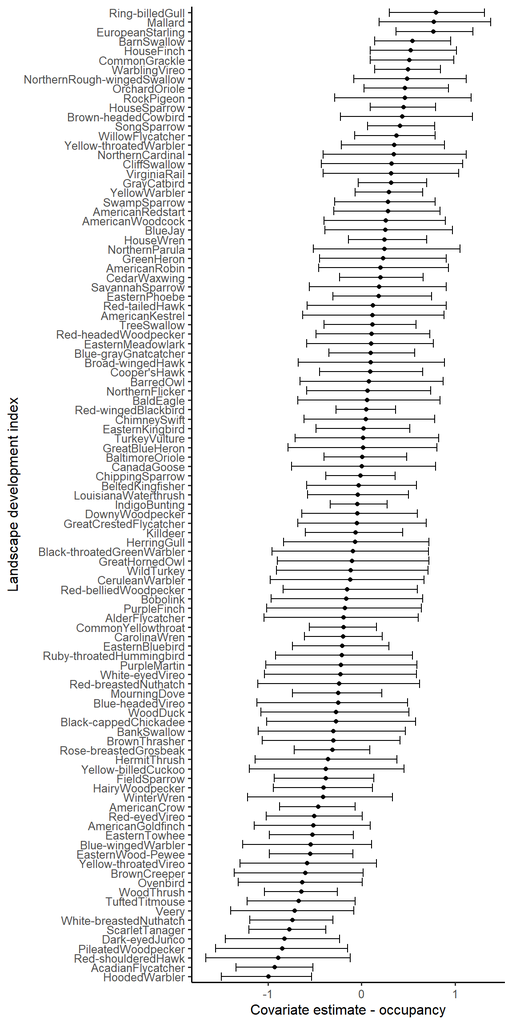

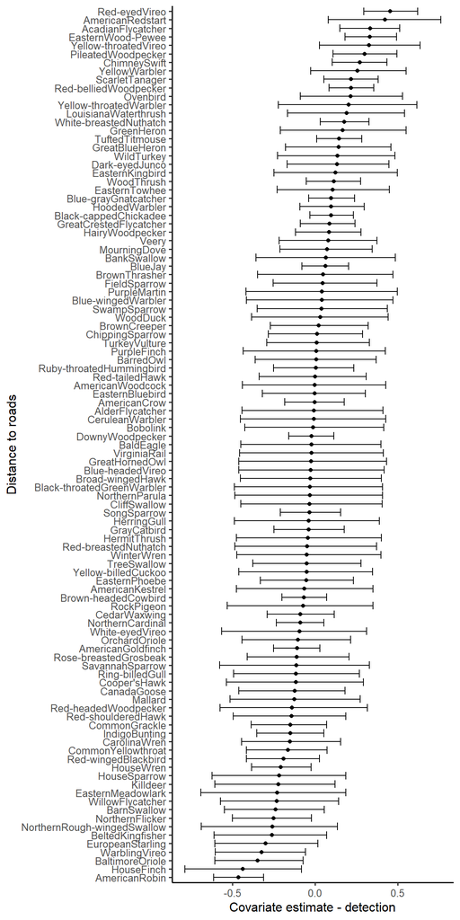

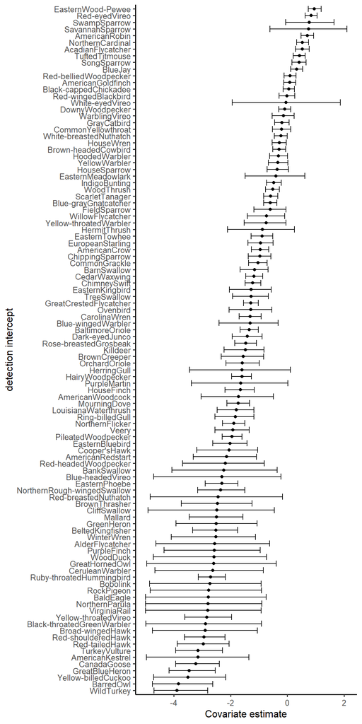

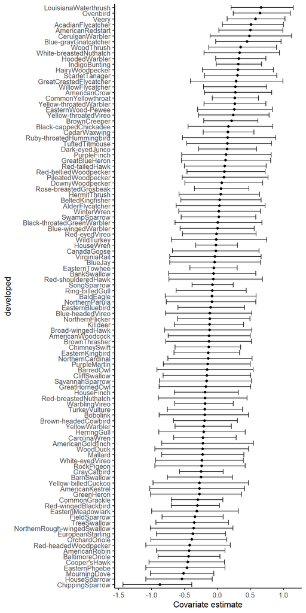

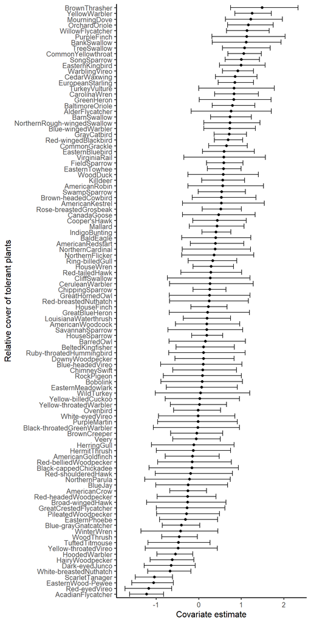

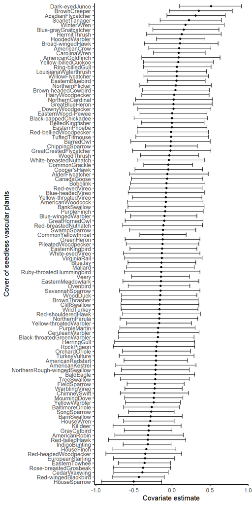

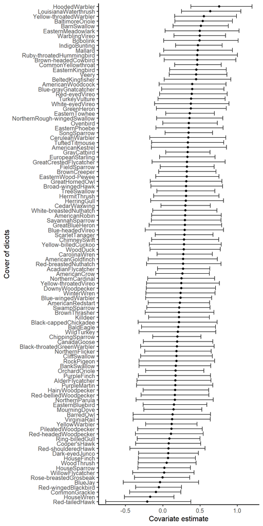

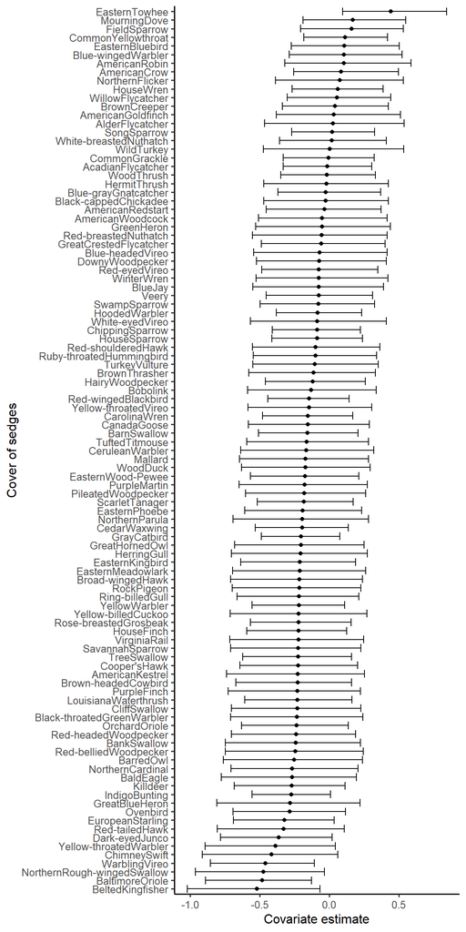

### covariates by migratory status

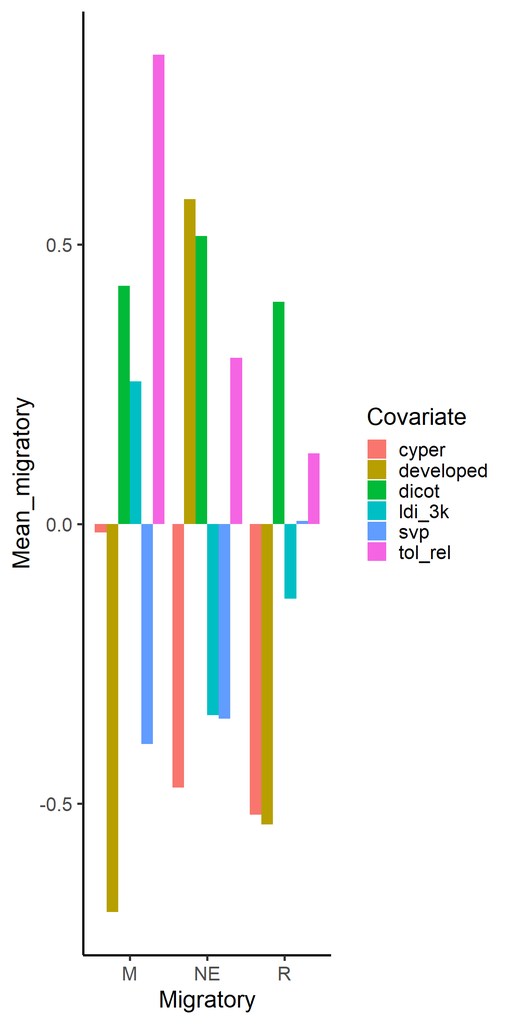